# Warehouse Location Problem

## Introduction

Here, let’s try to solve [Warehouse Location Problem](https://en.wikipedia.org/wiki/Facility_location_problem). In this problem, let’s say we have several customers location and location that available to build the warehouse. The task is to build warehouse and from what warehouse we send the goods to customers.

The decision:

- Where to build the warehouses
- What is the assignment of customers given the choosen warehouse

The Constrait:

- At least we build one warehouse
- One warehouse must be able to serve all customer

Let’s say we were the business owner who seek to expand our distribution to a new town. In accordance to do this, we need to establish new warehouse facilitations to distribute our goods given the location of our expected customers.

Let’s go!

Source:https://www.r-orms.org/mixed-integer-linear-programming/

here, we begin with building the problem around linear programming definition:

C={1…n} -> Set of customer

W={1…m} -> Set of possible warehouse

we also have cost function for the transportation cost from warehouse to customer also we have fixed cost for each warehouse that represent the cost of building the warehouse

Here is the formulation, it is being adapted from [German Wikipedia page](https://de.wikipedia.org/wiki/Warehouse_Location_Problem)

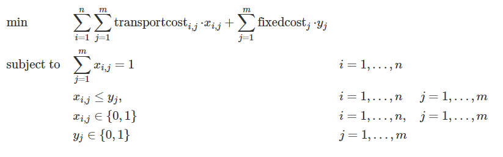

```r
#install.packages("knitr")
knitr::include_graphics("C:/Users/Randi/Pictures/Screenshot 2022-12-06 104948.png")
```

### 1.Generating Artificial Data

Produce customer coordinates based on uniform distribution

```r
set.seed(1234)
grid_size = 1000
n = 100
customer_locations = data.frame(
  id =1:n,
  x = round(runif(n) * grid_size),
  y = round(runif(n) * grid_size)
)
head(customer_locations)
```

|  | id | x | y |
| --- | --- | --- | --- |
| 1 | 1 | 114 | 35 |
| 2 | 2 | 622 | 565 |
| 3 | 3 | 609 | 280 |
| 4 | 4 | 623 | 204 |
| 5 | 5 | 861 | 134 |
| 6 | 6 | 640 | 326 |

Generating coordinates based on uniform distribution

```r
m= 20
warehouse_locations = data.frame(
  id = 1:m,
  x = round(runif(m)*grid_size),
  y = round(runif(m)*grid_size)
)
head(warehouse_locations)
```

|  | id | x | y |
| --- | --- | --- | --- |
| 1 | 1 | 661 | 422 |
| 2 | 2 | 528 | 31 |
| 3 | 3 | 317 | 258 |
| 4 | 4 | 768 | 335 |
| 5 | 5 | 526 | 134 |
| 6 | 6 | 732 | 500 |

Create fixed cost based on normal distribution

```r
fixedcost = round(rnorm(m, mean = grid_size * 10, sd = grid_size*5))
head(fixedcost)
```

```
[1]  9043  6090 20291 13753 19121 10400
```

Creating function to build transportation cost from i to j

```r
transportcost = function(i,j) {
  customer = customer_locations[i, ]
  warehouse = warehouse_locations[j, ]
  round(sqrt((customer$x-warehouse$x)^2+(customer$y-warehouse$y)^2))
}
transportcost(4,2)
```

```
[1] 197
```

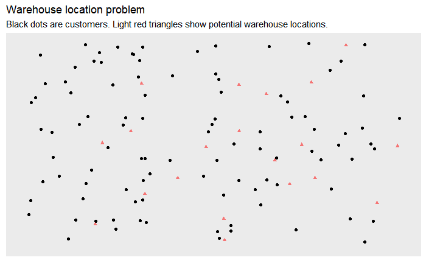

```r
library(ggplot2)
p <- ggplot(customer_locations, aes(x, y)) +
  geom_point() +
  geom_point(data = warehouse_locations, color = "red", alpha = 0.5, shape = 17) +
  scale_x_continuous(limits = c(0, grid_size)) +
  scale_y_continuous(limits = c(0, grid_size)) +
  theme(axis.title = element_blank(),
        axis.ticks = element_blank(),
        axis.text = element_blank(), panel.grid = element_blank())
p + ggtitle("Warehouse location problem",
          "Black dots are customers. Light red triangles show potential warehouse locations.")
```

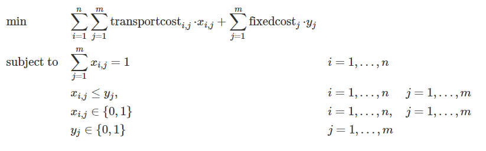

```r
#install.packages("knitr")
knitr::include_graphics("C:/Users/Randi/Pictures/Screenshot 2022-12-06 104948.png")
```

```r
#install.packages("ompr")
#install.packages("magritrr")
library(ompr)
library(magrittr)
model = MIPModel() %>%
  #===========================================Create Objective function=======================================
  # Add a variable to the model
  # 1 if i get assigned to warehouse j
  add_variable(x[i,j], i=1:n, j=1:m, type="binary")%>%

  # 1 if warehouse j is built
  add_variable(y[j], j=1:m, type="binary")%>%

  # Set model objective
  # maximize the preferences
  set_objective(sum_expr(transportcost(i,j)*x[i,j], i=1:n, j=1:m)+
                  sum_expr(fixedcost[j]*y[j], j=1:m), "min")%>%
  #==============================================Create Constraints===========================================
  # every customer needs to be assigned to a warehouse
  add_constraint(sum_expr(x[i,j], j=1:m)==1, i=1:n)%>%

  # if a customer is assigned to a warehouse, then the warehouse must be build
  add_constraint(x[i,j]<=y[j], i=1:n, j=1:m)
model
```

```
Mixed integer linear optimization problem
Variables:
  Continuous: 0
  Integer: 0
  Binary: 2020
Model sense: minimize
Constraints: 2100
```

```r
#install.packages("ompr.roi")
#install.packages("ROI.plugin.glpk")
library(ompr.roi)
library(ROI.plugin.glpk)
result <- solve_model(model, with_ROI(solver = "glpk", verbose = TRUE))
```

```
<SOLVER MSG>  ----
GLPK Simplex Optimizer, v4.65
2100 rows, 2020 columns, 6000 non-zeros
      0: obj =   0.000000000e+00 inf =   1.000e+02 (100)
    120: obj =   5.223300000e+04 inf =   0.000e+00 (0)
Perturbing LP to avoid stalling [322]...
Removing LP perturbation [1058]...
*  1058: obj =   3.322200000e+04 inf =   0.000e+00 (0) 2
OPTIMAL LP SOLUTION FOUND
GLPK Integer Optimizer, v4.65
2100 rows, 2020 columns, 6000 non-zeros
2020 integer variables, all of which are binary
Integer optimization begins...
Long-step dual simplex will be used
+  1058: mip =     not found yet >=              -inf        (1; 0)
+  1058: >>>>>   3.322200000e+04 >=   3.322200000e+04   0.0% (1; 0)
+  1058: mip =   3.322200000e+04 >=     tree is empty   0.0% (0; 1)
INTEGER OPTIMAL SOLUTION FOUND
<!SOLVER MSG> ----
```

Source =

[GLPK Solver](https://www.gnu.org/software/glpk/) [Why using long-step dual simplex](https://stackoverflow.com/questions/68929743/when-and-why-glpk-mi-switches-to-dual-simplex)

```r
suppressPackageStartupMessages(library(dplyr))
matching <- result %>%
  get_solution(x[i,j]) %>%
  filter(value > .9) %>%
  select(i, j)
matching
```

| i | j |
| --- | --- |
| 13 | 7 |
| 17 | 7 |
| 20 | 7 |
| 21 | 7 |
| 22 | 7 |
| 23 | 7 |
| 24 | 7 |
| 31 | 7 |
| 32 | 7 |
| 35 | 7 |

[output cut: 90 more lines]

Assign value to the previous plot

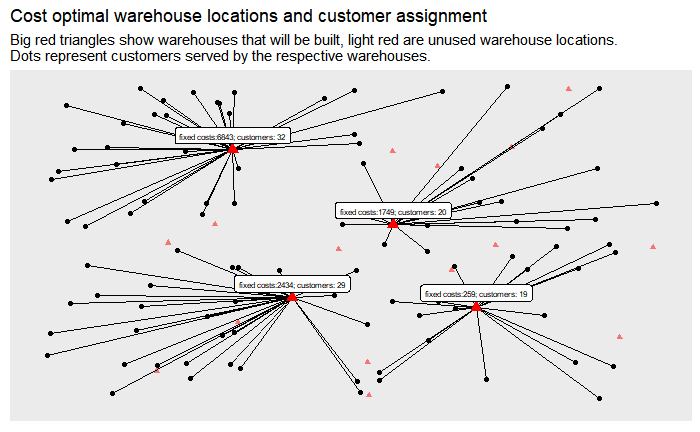

```r
plot_assignment <- matching %>%
  inner_join(customer_locations, by = c("i" = "id")) %>%
  inner_join(warehouse_locations, by = c("j" = "id"))
customer_count <- matching %>% group_by(j) %>% summarise(n = n()) %>% rename(id = j)
plot_warehouses <- warehouse_locations %>%
  mutate(costs = fixedcost) %>%
  inner_join(customer_count, by = "id") %>%
  filter(id %in% unique(matching$j))
p +
  geom_segment(data = plot_assignment, aes(x = x.y, y = y.y, xend = x.x, yend = y.x)) +
  geom_point(data  = plot_warehouses, color = "red", size = 3, shape = 17) +
  ggrepel::geom_label_repel(data  = plot_warehouses,
                            aes(label = paste0("fixed costs:", costs, "; customers: ", n)),
                            size = 2, nudge_y = 20) +
  ggtitle(paste0("Cost optimal warehouse locations and customer assignment"),
          "Big red triangles show warehouses that will be built, light red are unused warehouse locations.
Dots represent customers served by the respective warehouses.")
```

```r
sum(fixedcost[unique(matching$j)])
```

```
[1] 11285
```